# **Hypothesis Testing**

Giorgi Nikolaishvili EC 320: Introduction to Econometrics University of Oregon

Spring 2022

## Recap

Common workflow:

- Load `pacman` package, then use `p_load()` to install+load packages
- Gather tidy data into a data frame or tibble
- **Data manipulation:**
  - Select subsets of variables using `select()`
  - Filter observations using `filter()`
  - Edit existing variables or create new ones using `mutate()`
  - Order observations using `arrange()`
  - Slice data using `group_by()`
  - Summarize data using `summarize()`
  - Use the pipe operator `%>%` (available through `tidyverse`) or `|>` (available through base R)!
- Plot data using tools provided by the `ggplot2` package
- Estimate linear regression models using `lm()`
- Present output using `modelsummary()` (available through the `modelsummary` package)
- Retrieve coefficient estimates, standard errors, etc. using `summary()`

Today we will draw upon many of the items in the above list, as we work through a regression analysis project together in a fresh .Rmd file.

## Load Packages

Load the following packages:

- `tidyverse` – this will be used for data manipulation, plotting, etc.
- `gapminder` – provides us with data
- `modelsummary` – gives us access to the `modelsummary()` function for presenting regression outputs

```r
library(pacman)
p_load(tidyverse, gapminder, modelsummary)
```

## Manipulate Data

Take a look at the first few observations of the `gapminder` dataset:

```r
head(gapminder)
```

```
## # A tibble: 6 x 6
##   country     continent  year lifeExp      pop gdpPercap
##   <fct>       <fct>     <int>   <dbl>    <int>     <dbl>
## 1 Afghanistan Asia       1952    28.8  8425333      779.
## 2 Afghanistan Asia       1957    30.3  9240934      821.
## 3 Afghanistan Asia       1962    32.0 10267083      853.
## 4 Afghanistan Asia       1967    34.0 11537966      836.
## 5 Afghanistan Asia       1972    36.1 13079460      740.
## 6 Afghanistan Asia       1977    38.4 14880372      786.
```

Standardize the `pop`, `lifeExp`, and `gdpPercap` variables in `gapminder` **by year**, and store the resulting data frame in an object called `data_df`:

```r
data_df <- gapminder |>
            group_by(year) |>
            mutate(pop = (pop - mean(pop))/sd(pop),
                   lifeExp = (lifeExp - mean(lifeExp))/sd(lifeExp),
                   gdpPercap = (gdpPercap - mean(gdpPercap))/sd(gdpPercap)) |>
            ungroup()
head(data_df)
```

```
## # A tibble: 6 x 6
##   country     continent  year lifeExp    pop gdpPercap
##   <fct>       <fct>     <int>   <dbl>  <dbl>     <dbl>
## 1 Afghanistan Asia       1952   -1.66 -0.147    -0.316
## 2 Afghanistan Asia       1957   -1.73 -0.145    -0.352
## 3 Afghanistan Asia       1962   -1.79 -0.145    -0.447
## 4 Afghanistan Asia       1967   -1.85 -0.142    -0.574
## 5 Afghanistan Asia       1972   -1.89 -0.137    -0.568
## 6 Afghanistan Asia       1977   -1.88 -0.131    -0.781
```

Store observations from 1957 and 1997 into separate objects called `data57_df` and `data97_df`, respectively.

```r
data57_df <- data_df %>%
              filter(year == 1957)

data97_df <- data_df %>%
              filter(year == 1997)

rm(data_df)
```

Print the first few observations of `data57_df` to make sure all has been done correctly.

```r
head(data57_df)
```

```
## # A tibble: 6 x 6
##   country     continent  year lifeExp     pop gdpPercap
##   <fct>       <fct>     <int>   <dbl>   <dbl>     <dbl>
## 1 Afghanistan Asia       1957  -1.73  -0.145    -0.352
## 2 Albania     Europe     1957   0.635 -0.264    -0.239
## 3 Algeria     Africa     1957  -0.476 -0.130    -0.130
## 4 Angola      Africa     1957  -1.59  -0.217    -0.0478
## 5 Argentina   Americas   1957   1.05   0.0129    0.259
## 6 Australia   Oceania    1957   1.54  -0.138     0.674
```

Print the first few observations of `data97_df` to make sure all has been done correctly.

```r
head(data97_df)
```

```
## # A tibble: 6 x 6
##   country     continent  year lifeExp     pop gdpPercap
##   <fct>       <fct>     <int>   <dbl>   <dbl>     <dbl>
## 1 Afghanistan Asia       1997  -2.01  -0.125     -0.831
## 2 Albania     Europe     1997   0.686 -0.265     -0.580
## 3 Algeria     Africa     1997   0.358 -0.0732    -0.422
## 4 Angola      Africa     1997  -2.08  -0.217     -0.670
## 5 Argentina   Americas   1997   0.715 -0.0198     0.185
## 6 Australia   Oceania    1997   1.20  -0.152      1.76
```

## Plot Data

Let’s separately plot the cross-sections of `lifeExp` and `pop` for 1957 and 1997, respectively.

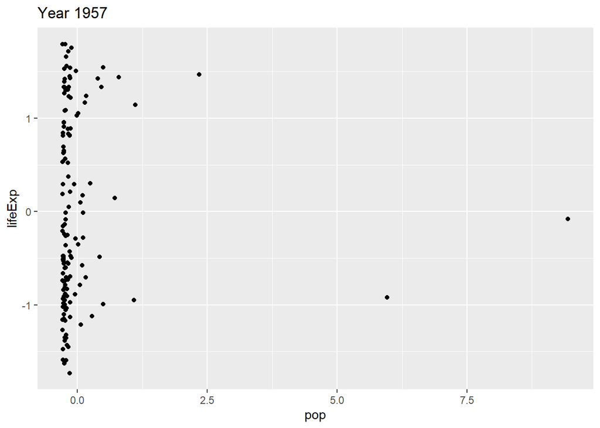

```r
ggplot(data57_df, aes(x = pop, y = lifeExp)) +
    labs(title = "Year 1957") +
    geom_point()
```

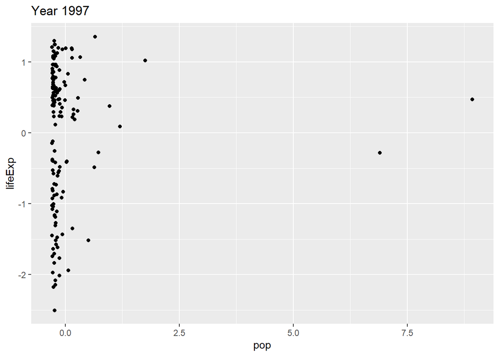

```r
ggplot(data97_df, aes(x = pop, y = lifeExp))  +
    labs(title = "Year 1997") +
    geom_point()
```

Are the above plots helpful? Not really – outliers in the `pop` dimension are stretching the plots and making them uninformative.

We can deal with this by removing such outliers from the plots. Make the same plots, but this time exclude the major outliers.

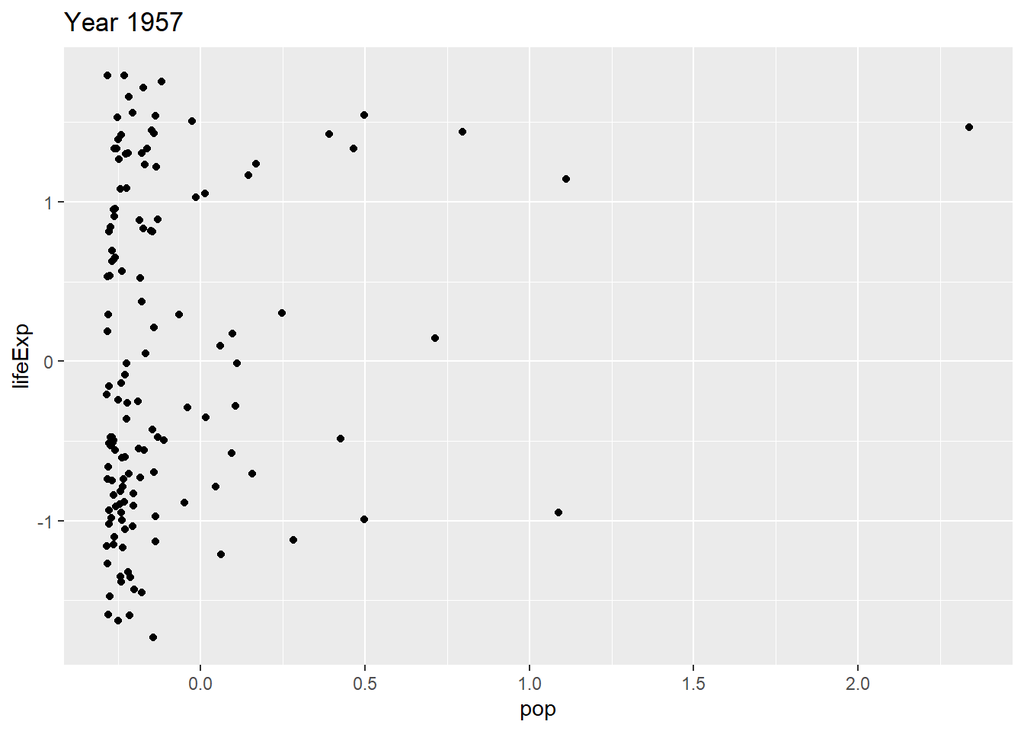

```r
ggplot(data57_df %>% filter(abs(pop) < 3), aes(x = pop, y = lifeExp)) +
    labs(title = "Year 1957") +
    geom_point()
```

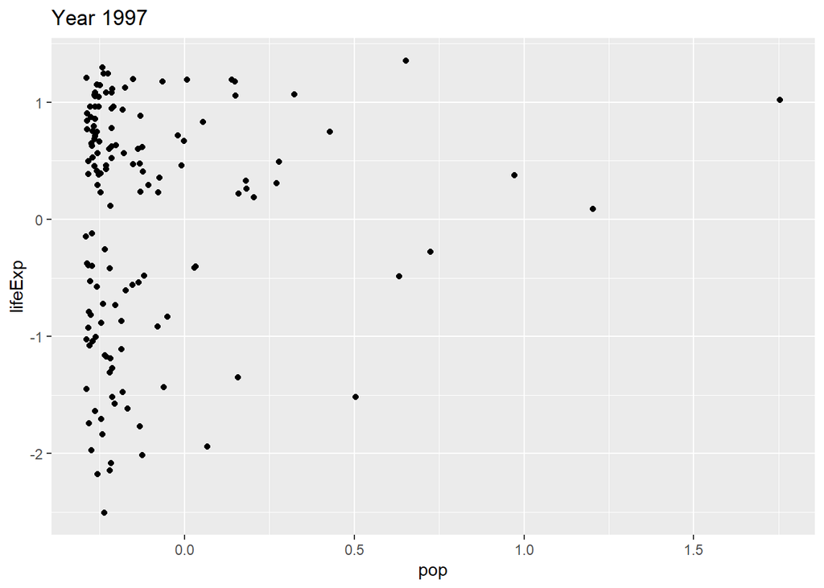

```r
ggplot(data97_df %>% filter(abs(pop) < 3), aes(x = pop, y = lifeExp))  +
    labs(title = "Year 1997") +
    geom_point()
```

Is there any kind of clear relationship between `pop` and `lifeExp`?

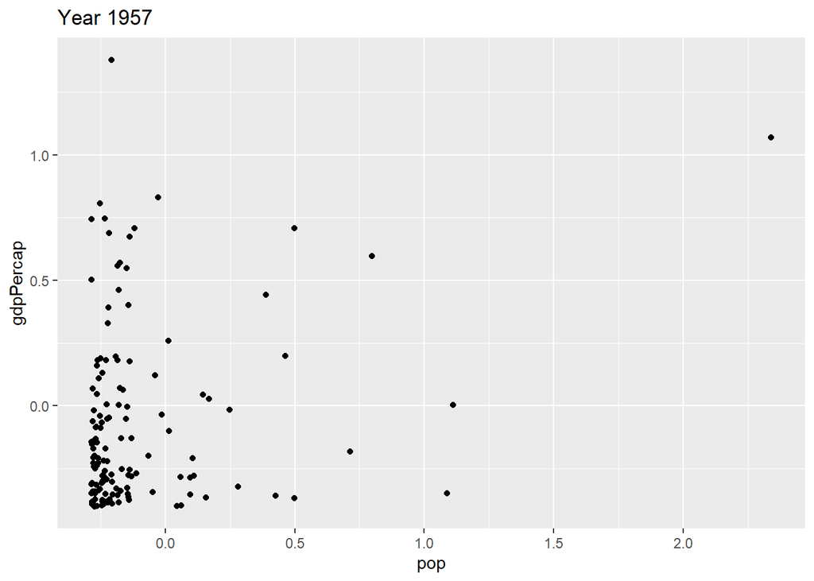

```r
ggplot(data57_df %>% filter(abs(pop) < 3, abs(gdpPercap) < 3), aes(x = pop, y = gdpPercap)) +
    labs(title = "Year 1957") +
    geom_point()
```

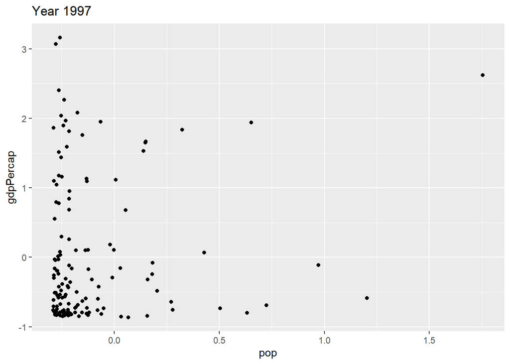

```r
ggplot(data97_df %>% filter(abs(pop) < 3), aes(x = pop, y = gdpPercap))  +
    labs(title = "Year 1997") +
    geom_point()
```

Is there any kind of clear relationship between `pop` and `gdpPercap`?

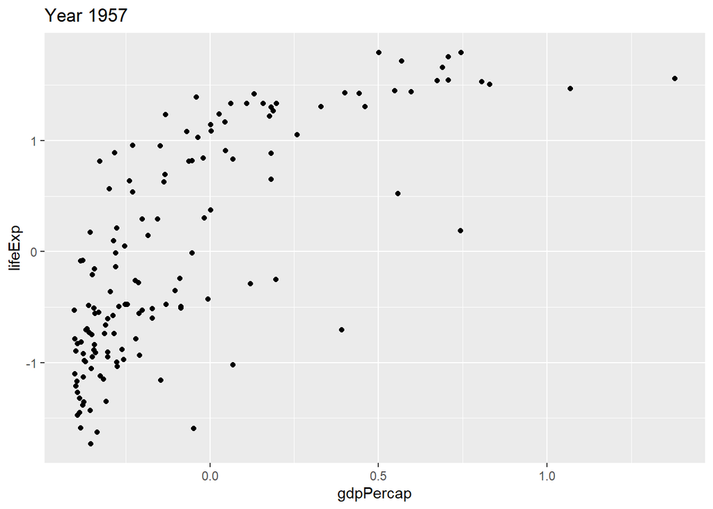

```r
ggplot(data57_df %>% filter(abs(lifeExp) < 3, abs(gdpPercap) < 3), aes(x = gdpPercap, y = lifeExp)) +
    labs(title = "Year 1957") +
    geom_point()
```

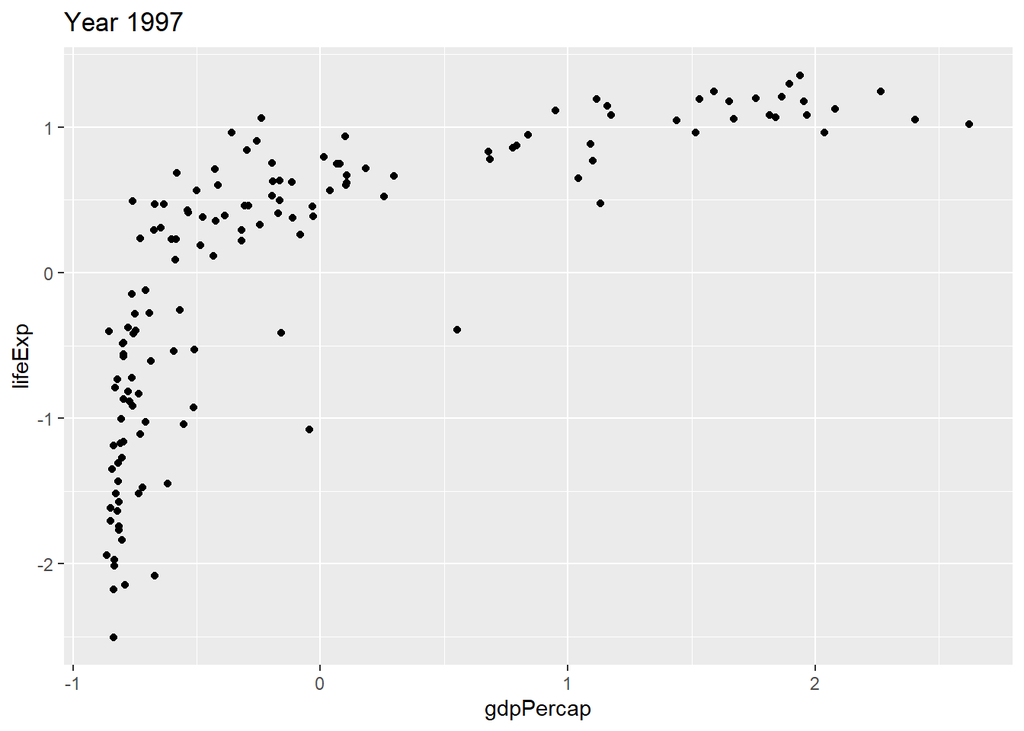

```r
ggplot(data97_df %>% filter(abs(lifeExp) < 3, abs(gdpPercap) < 3), aes(x = gdpPercap, y = lifeExp))  +
    labs(title = "Year 1997") +
    geom_point()
```

Is there any kind of clear relationship between `lifeExp` and `gdpPercap`?

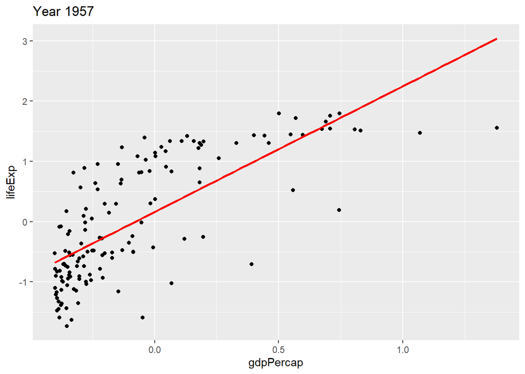

```r
ggplot(data57_df %>% filter(abs(lifeExp) < 3, abs(gdpPercap) < 3), aes(x = gdpPercap, y = lifeExp)) +
    labs(title = "Year 1957") +
    geom_point() +
    geom_smooth(method = "lm", se = FALSE, color = "red")
```

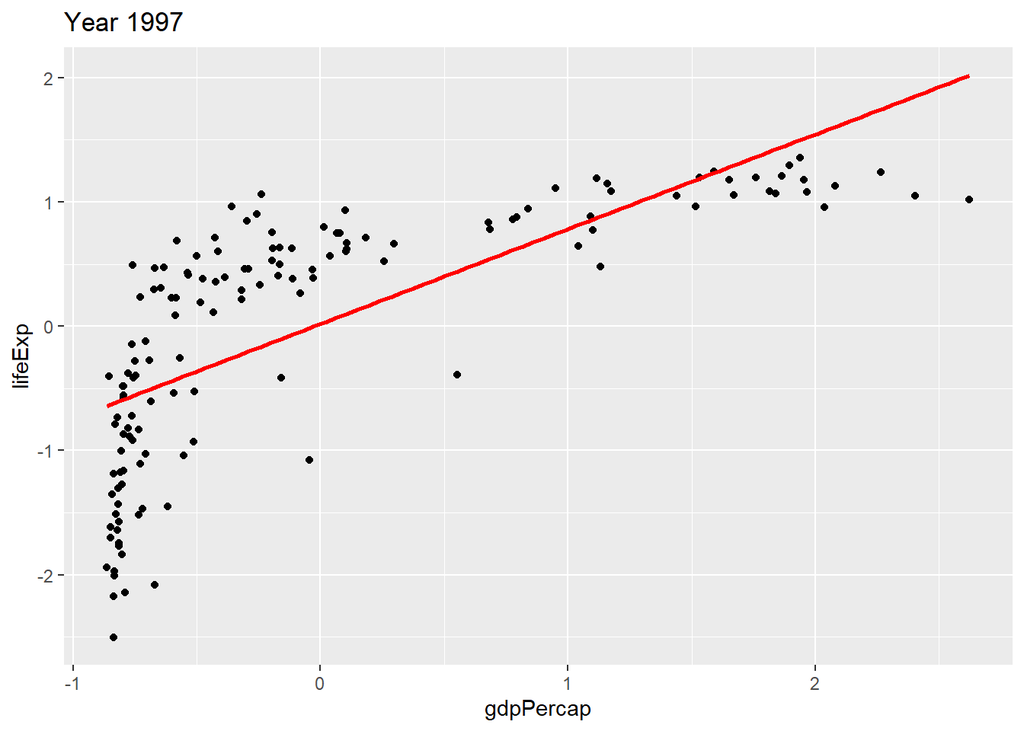

```r
ggplot(data97_df %>% filter(abs(lifeExp) < 3, abs(gdpPercap) < 3), aes(x = gdpPercap, y = lifeExp))  +
    labs(title = "Year 1997") +
    geom_point() +
    geom_smooth(method = "lm", se = FALSE, color = "red")
```

## Estimate Regression Models

Regress `lifeExp` on `gdpPercap` for the 1957 and 1997 samples separately:

```r
mod57 <- lm(formula = lifeExp ~ gdpPercap, data = data57_df)
mod97 <- lm(formula = lifeExp ~ gdpPercap, data = data97_df)
```

Present the results of these regressions together in a table using `modelsummary()`:

```r
models <- list("Model '57" = mod57, "Model '97" = mod97)
modelsummary(models, stars = TRUE)
```

|  | Model ’57 | Model ’97 |
| --- | --- | --- |
| (Intercept) | 0.000 | 0.000 |
|  | (0.080) | (0.060) |
| gdpPercap | 0.304*** | 0.704*** |
|  | (0.081) | (0.060) |
| Num.Obs. | 142 | 142 |
| R2 | 0.092 | 0.495 |
| R2 Adj. | 0.086 | 0.492 |
| AIC | 394.2 | 310.9 |
| BIC | 403.1 | 319.8 |
| Log.Lik. | -194.115 | -152.464 |
| F | 14.229 | 137.290 |
| RMSE | 0.96 | 0.71 |

+ p < 0.1, * p < 0.05, ** p < 0.01, *** p < 0.001

## Test Hypotheses

### Two-Sided Tests

First, let us manually test whether the effect of `gdpPercap` on `lifeExp` is **nonzero** with a 99% level of confidence for the ’57 and ’97 sample regressions. Note that this implies we must carry out a two-sided test on the $\beta_1$ coefficient estimate in both models, with our test statistic distribution being the $t$-distribution.

- $H_0$: $\beta_1 = 0$
- $H_1$: $\beta_1 \neq 0$

Separately pass the ’57 and ’97 regression model outputs into `summary()`, and store as new objects `modsum57` and `modsum97`, respectively.

```r
modsum57 <- summary(mod57)
modsum97 <- summary(mod97)
```

Store the degrees of freedom of both regressions as objects `dof57` and `dof97`, respectively. If these two values are the same, then just store them into an object called `dof` and remove `dof57` and `dof97` from the work environment.

```r
dof57 <- modsum57$df[2]
dof97 <- modsum97$df[2]
if (dof57 == dof97){
  dof <- dof57
  rm(dof57, dof97)
  print(dof)
}
```

```
## [1] 140
```

Using the above degrees of freedom, store the $t$-stats associated with a two-sided $p$-value of 0.01 (99% level of confidence) for the ’57 and ’97 samples into objects `t_double99_57` and `t_double99_97`, respectively.

```r
t_double99_57 <- qt(0.995, dof)
t_double99_97 <- qt(0.995, dof)
```

Now store the $t$-stats associated with our desired test as objects `t_57` and `t_97`, respectively:

```r
t_57 <- (modsum57$coefficients[2,1] - 0) / modsum57$coefficients[2,2]
t_97 <- (modsum97$coefficients[2,1] - 0) / modsum97$coefficients[2,2]
```

Create objects `test57` and `test97` that take the value `TRUE` if the null hypothesis is rejected, and `FALSE` otherwise.

```r
test57 <- abs(t_57) > t_double99_57
test97 <- abs(t_97) > t_double99_97
```

Suppose we want to conduct the same kind of test, but this time we want to check whether $\beta_1 \neq 1$. Carry out the same process as above, but this time in a single code chunk. Note that you may reuse `t_double99_57` and `t_double99_97`.

```r
t_57 <- (modsum57$coefficients[2,1] - 1) / modsum57$coefficients[2,2]
t_97 <- (modsum97$coefficients[2,1] - 1) / modsum97$coefficients[2,2]
test57 <- abs(t_57) > t_double99_57
test97 <- abs(t_97) > t_double99_97
```

### One-Sided Tests

Carry out the following test with a 95% level of confidence on both samples:

- $H_0$: $\beta_1 \geq 1$
- $H_1$: $\beta_1 < 1$

```r
 # Save critical t-stat
t_less95 <- qt(0.05, dof)

# Create test t-stats
t_57 <- (modsum57$coefficients[2,1] - 1) / modsum57$coefficients[2,2]
t_97 <- (modsum97$coefficients[2,1] - 1) / modsum97$coefficients[2,2]

# Compare test t-stats with critical t-stat
# (TRUE if null is rejected, FALSE otherwise)
test57 <- t_57 < t_less95
test97 <- t_97 < t_less95

#
# Print 1957 test result
#
if (test57 == TRUE){
  print("For the 1957 sample, the null hypothesis is rejected with a 95% level of confidence.")
}else{
  print("For the 1957 sample, the null hypothesis cannot be rejected with a 95% level of confidence.")
}
```

```
## [1] "For the 1957 sample, the null hypothesis is rejected with a 95% level of confidence."
```

```r
#
# Print 1997 test result
#
if (test97 == TRUE){
  print("For the 1997 sample, the null hypothesis is rejected with a 95% level of confidence.")
}else{
  print("For the 1997 sample, the null hypothesis cannot be rejected with a 95% level of confidence.")
}
```

```
## [1] "For the 1997 sample, the null hypothesis is rejected with a 95% level of confidence."
```

Carry out the following test with a 95% level of confidence on both samples:

- $H_0$: $\beta_1 \leq -1$
- $H_1$: $\beta_1 > -1$

```r
t_greater95 <- qt(0.95, dof) # Save critical t-stat
t_57 <- (modsum57$coefficients[2,1] - (-1)) / modsum57$coefficients[2,2]
t_97 <- (modsum97$coefficients[2,1] - (-1)) / modsum97$coefficients[2,2]
test57 <- t_57 > t_greater95
test97 <- t_97 > t_greater95

#
# Print 1957 test result
#
if (test57 == TRUE){
  print("For the 1957 sample, the null hypothesis is rejected with a 95% level of confidence.")
}else{
  print("For the 1957 sample, the null hypothesis cannot be rejected with a 95% level of confidence.")
}
```

```
## [1] "For the 1957 sample, the null hypothesis is rejected with a 95% level of confidence."
```

```r
#
# Print 1997 test result
#
if (test97 == TRUE){
  print("For the 1997 sample, the null hypothesis is rejected with a 95% level of confidence.")
}else{
  print("For the 1997 sample, the null hypothesis cannot be rejected with a 95% level of confidence.")
}
```

```
## [1] "For the 1997 sample, the null hypothesis is rejected with a 95% level of confidence."
```

Carry out the following test with a 99% level of confidence on both samples:

- $H_0$: $\beta_1 \leq 0.5$
- $H_1$: $\beta_1 > 0.5$

```r
t_greater99 <- qt(0.99, dof)
t_57 <- (modsum57$coefficients[2,1] - (0.5)) / modsum57$coefficients[2,2]
t_97 <- (modsum97$coefficients[2,1] - (0.5)) / modsum97$coefficients[2,2]
test57 <- t_57 > t_greater99
test97 <- t_97 > t_greater99

#
# Print 1957 test result
#
if (test57 == TRUE){
  print("For the 1957 sample, the null hypothesis is rejected with a 99% level of confidence.")
}else{
  print("For the 1957 sample, the null hypothesis cannot be rejected with a 99% level of confidence.")
}
```

```
## [1] "For the 1957 sample, the null hypothesis cannot be rejected with a 99% level of confidence."
```

```r
#
# Print 1997 test result
#
if (test97 == TRUE){
  print("For the 1997 sample, the null hypothesis is rejected with a 99% level of confidence.")
}else{
  print("For the 1997 sample, the null hypothesis cannot be rejected with a 99% level of confidence.")
}
```

```
## [1] "For the 1997 sample, the null hypothesis is rejected with a 99% level of confidence."
```